# The Largest Impact Weather Events on Health and Economic Across the United States

zhouyanhui

October 18, 2015

# Synopsis

The basic goal of this analysis is to explore the NOAA Storm Database and the questions below about severe weather events.

1. Across the United States, which types of events are most harmful with respect to population health?
2. Across the United States, which types of events have the greatest economic consequences?

After analysis, the result shows, from 1950 to November 2011:

- tornados are the most harmful with respect to population health, which have led to 5633 fatalities and 91346 injuries.
- floods are the greatest economic consequences, which have caused over 150 billion dollars economic damange.

# Data Processing

## Read and check the data

Read data from raw data file

```r
weatherdata <- read.csv(bzfile("repdata-data-StormData.csv.bz2"))
```

Check data rows and colums

```r
dim(weatherdata)
```

```
## [1] 902297     37
```

```r
names(weatherdata)
```

```
##  [1] "STATE__"    "BGN_DATE"   "BGN_TIME"   "TIME_ZONE"  "COUNTY"
##  [6] "COUNTYNAME" "STATE"      "EVTYPE"     "BGN_RANGE"  "BGN_AZI"
## [11] "BGN_LOCATI" "END_DATE"   "END_TIME"   "COUNTY_END" "COUNTYENDN"
## [16] "END_RANGE"  "END_AZI"    "END_LOCATI" "LENGTH"     "WIDTH"
## [21] "F"          "MAG"        "FATALITIES" "INJURIES"   "PROPDMG"
## [26] "PROPDMGEXP" "CROPDMG"    "CROPDMGEXP" "WFO"        "STATEOFFIC"
## [31] "ZONENAMES"  "LATITUDE"   "LONGITUDE"  "LATITUDE_E" "LONGITUDE_"
## [36] "REMARKS"    "REFNUM"
```

## Process data

In this analysis, need to use this variables: ‘EVTYPE’,‘FATALITIES’,‘INJURIES’, ‘PROPDMG’, ‘PROPDMGEXP’, ‘CROPDMG’, ‘CROPDMGEXP’.

**Filter useful data from original storm data.**

```r
eeData <- weatherdata[,c('EVTYPE','FATALITIES','INJURIES', 'PROPDMG', 'PROPDMGEXP', 'CROPDMG', 'CROPDMGEXP')]
```

**Check variables**

```r
head(eeData)
```

```
##    EVTYPE FATALITIES INJURIES PROPDMG PROPDMGEXP CROPDMG CROPDMGEXP
## 1 TORNADO          0       15    25.0          K       0
## 2 TORNADO          0        0     2.5          K       0
## 3 TORNADO          0        2    25.0          K       0
## 4 TORNADO          0        2     2.5          K       0
## 5 TORNADO          0        2     2.5          K       0
## 6 TORNADO          0        6     2.5          K       0
```

```r
type_num <- length(unique(eeData$EVTYPE))
```

There is 985 of event types.

```r
str(unique(eeData$FATALITIES))
```

```
##  num [1:52] 0 1 4 6 7 2 5 25 3 10 ...
```

```r
str(unique(eeData$INJURIES))
```

```
##  num [1:200] 15 0 2 6 1 14 3 26 12 50 ...
```

The value of FATALITIES and INJURIES are numbers.

```r
str(unique(eeData$PROPDMG))
```

```
##  num [1:1390] 25 2.5 250 0 0.03 0.25 5 0.1 50 500 ...
```

```r
str(unique(eeData$CROPDMG))
```

```
##  num [1:432] 0 10 500 1 4 50 5 15 0.5 0.4 ...
```

The value of PROPDMG and CROPDMG are both numeric.

```r
str(unique(eeData$PROPDMGEXP))
```

```
##  Factor w/ 19 levels "","+","-","0",..: 16 17 1 14 19 2 4 9 10 13 ...
```

```r
str(unique(eeData$CROPDMGEXP))
```

```
##  Factor w/ 9 levels "","0","2","?",..: 1 7 6 9 5 4 2 8 3
```

The value of PROPDMGEXP and CROPDMGEXP are unit of PROPDMG and CROPDMG respectively. According to the document, “H” for hundreds, “K” for thousands, “M” for millions, and “B” for billions, and others not mentioned will be ignored.

**Process the data, about harmful with respect to population health** Sum FATALITIES and INJURIES for each EVTYPE respectively, and merge to one dataset.

```r
suppressMessages(library(dplyr))
fatalitiesData <- aggregate(FATALITIES ~ EVTYPE, data=eeData, sum)
injuriesData <- aggregate(INJURIES ~ EVTYPE, data=eeData, sum)
healthHarmData <- merge(fatalitiesData, injuriesData, by="EVTYPE")
healthHarmData <- arrange(healthHarmData, -FATALITIES, -INJURIES)
```

**Process the data, about economic consequences** Convert numeric of damage value with unit to dollar number. And then sum the property damage and crop damage for each EVTYPE.

```r
eeData$propDmgAmout <- 0
idx <- toupper(eeData$PROPDMGEXP) == 'H'
eeData$propDmgAmout[idx] <- eeData$PROPDMG[idx] * 100
idx <- toupper(eeData$PROPDMGEXP) == 'K'
eeData$propDmgAmout[idx] <- eeData$PROPDMG[idx] * 1000
idx <- toupper(eeData$PROPDMGEXP) == 'M'
eeData$propDmgAmout[idx] <- eeData$PROPDMG[idx] * 10^6
idx <- toupper(eeData$PROPDMGEXP) == 'B'
eeData$propDmgAmout[idx] <- eeData$PROPDMG[idx] * 10^9

eeData$cropDmgAmout <- 0
idx <- toupper(eeData$CROPDMGEXP) == 'H'
eeData$cropDmgAmout[idx] <- eeData$CROPDMG[idx] * 100
idx <- toupper(eeData$CROPDMGEXP) == 'K'
eeData$cropDmgAmout[idx] <- eeData$CROPDMG[idx] * 1000
idx <- toupper(eeData$CROPDMGEXP) == 'M'
eeData$cropDmgAmout[idx] <- eeData$CROPDMG[idx] * 10^6
idx <- toupper(eeData$CROPDMGEXP) == 'B'
eeData$cropDmgAmout[idx] <- eeData$CROPDMG[idx] * 10^9

economicDmg <- aggregate(propDmgAmout + cropDmgAmout ~ EVTYPE, data=eeData, sum)
names(economicDmg) <- c("EVTYPE", "economicDmg")
economicDmg <- arrange(economicDmg, -economicDmg)
```

# Results

## The most harmful event with respect to population health

Show FATALITIES and INJURIES with the top 9 harmful weather events in one figure.

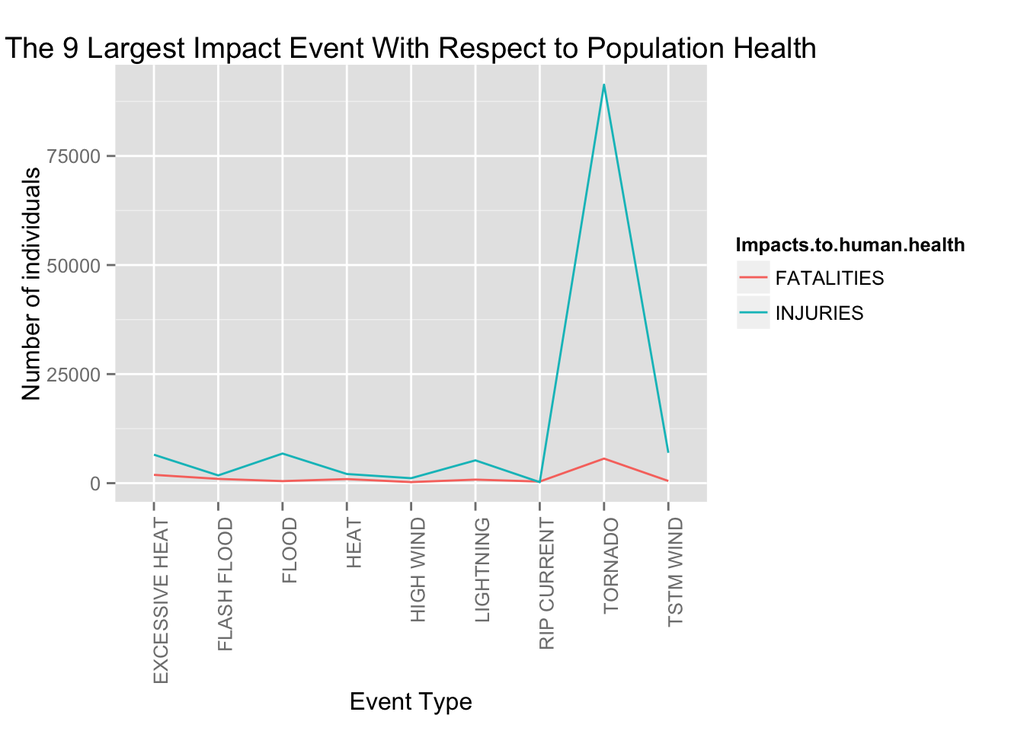

```r
suppressMessages(library(reshape2))
suppressMessages(library(ggplot2))
df <- healthHarmData[1:9, ]
dfm <- melt(df, id.vars = 'EVTYPE', variable.name = 'Impacts.to.human.health')
p <- ggplot(dfm, aes(x = EVTYPE, y = value, group =Impacts.to.human.health))
p <- p+ geom_line(aes(colour=Impacts.to.human.health))
p <- p+ theme(axis.text.x = element_text(angle = 90, hjust = 1))
p <- p + xlab("Event Type") + ylab("Number of individuals") + ggtitle("The 9 Largest Impact Event With Respect to Population Health")
print(p)
```

This figure shows the most fatalities and injuries are both caused by TORNADO.

So, **The most harmful event with respect to population health is TORNADO**, it cause 5633 fatalities and 91346 injuries.

## The greatest economic consequences event

Show the top 9 great economic consequences in a figure.

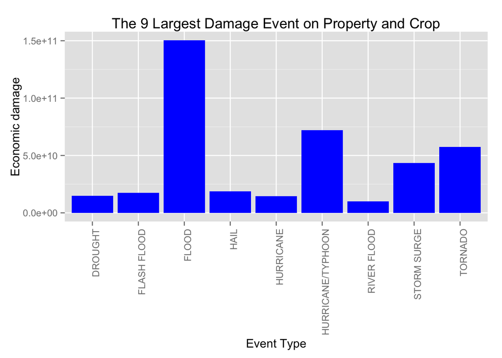

```r
df <- economicDmg[1:9, ]
p <- ggplot(df, aes(x=EVTYPE, y=economicDmg))
p <- p + geom_bar(fill = "blue", stat = "identity")
p <- p + theme(axis.text.x = element_text(angle = 90, hjust = 1))
p <- p + xlab("Event Type") + ylab("Economic damage") + ggtitle("The 9 Largest Damage Event on Property and Crop")
print(p)
```

This figure shows the FLOOD event has the highest bar.

So, **The greatest economic consequences event is FLOOD**, the economic damage is up to 150319678250 dollars.